# Analysis of Longitudinal Data (week 6)

When analyzing longitudinal data, difficulties can arise because of assumptions we are making about the data. In longitudinal data, multiple measurements of the same variables are taken from the same subjects over time. Measurements taken from the same subject are likely to be correlated, which can complicate statistical analysis. Additionally, there is random variation present between subjects that may need to be taken into consideration.

We have two data sets that have been used as examples in MABS [@mabs]: the RATS data set[^1], which contains growth data for different groups of rats and the BPRS (Brief Psychiatric Rating Scale) data set[^2], which contains psychiatric scores for subjects in different treatment groups. Both of these data sets have been measured from the subjects over time, so measurements of the same variables have been performed at different time intervals. These data sets can give information about how different processes behave over time, for example what conditions produce the fastest rat growth.

```r
rats <- read.csv("./data/rats.csv")
rats$ID <- as.factor(rats$ID)
rats$Group <- as.factor(rats$Group)
summary(rats)

bprs <- read.csv("./data/bprs.csv")
bprs$subject <- as.factor(bprs$subject)
bprs$treatment <- as.factor(bprs$treatment)
summary(bprs)
```

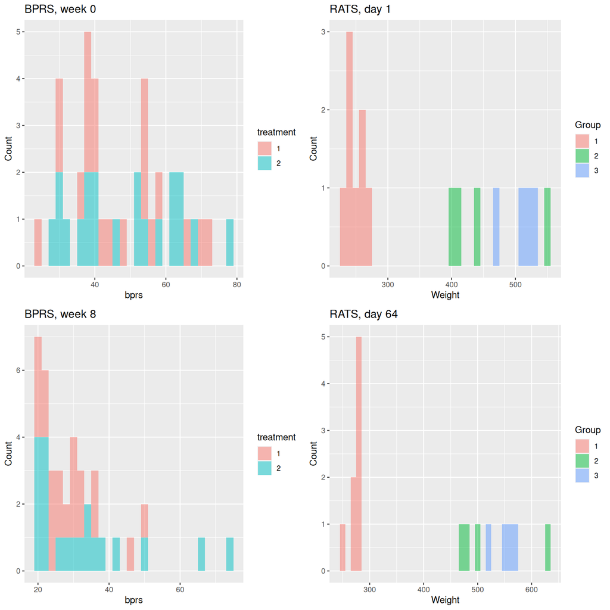

Histograms for BPRS (left) and RATS (right) data sets.

```r
h1 <- ggplot(bprs %>% filter(week <= 0), aes(bprs, fill = treatment)) +
  geom_histogram(alpha = 0.5, binwidth=2) + ylab("Count") + ggtitle("BPRS, week 0")
h2 <- ggplot(rats %>% filter(Time <= 1), aes(Weight, fill = Group)) +
  geom_histogram(alpha = 0.5, binwidth=10) + ylab("Count") + ggtitle("RATS, day 1")
h3 <- ggplot(bprs %>% filter(week >= 8), aes(bprs, fill = treatment)) +
  geom_histogram(alpha = 0.5, binwidth=2) + ylab("Count") + ggtitle("BPRS, week 8")
h4 <- ggplot(rats %>% filter(Time >= 64), aes(Weight, fill = Group)) +
  geom_histogram(alpha = 0.5, binwidth=10) + ylab("Count") + ggtitle("RATS, day 64")

grid.arrange(h1, h2, h3, h4, ncol=2, nrow=2)
```

## RATS

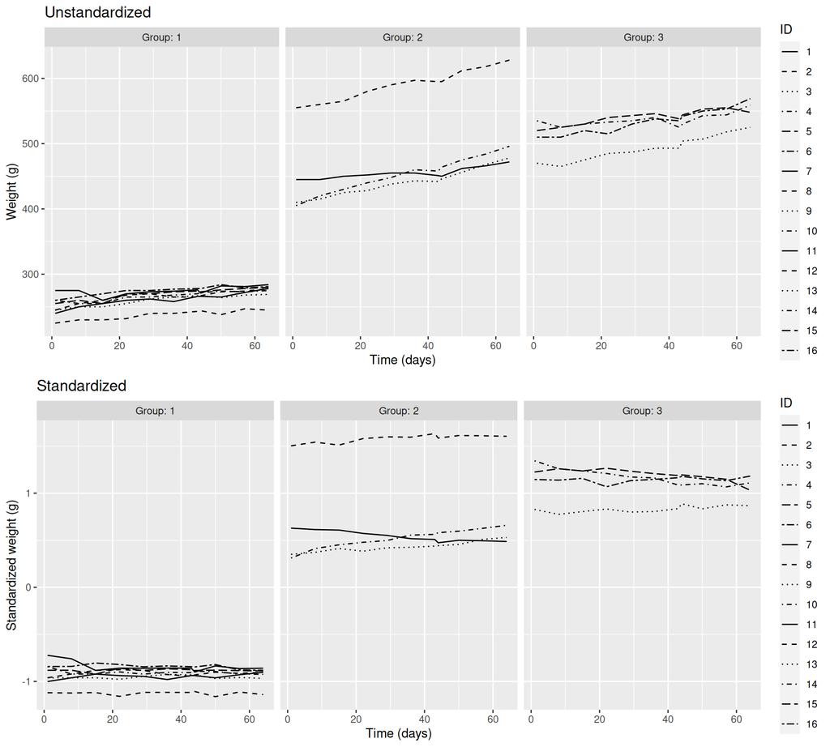

RATS data set weight for different groups: unstandardized (top) and standardized (bottom).

```r
# standardize data set
rats_std <- rats %>%
  group_by(Time) %>%
  mutate(Weight_std = (Weight - mean(Weight))/sd(Weight)) %>%
  ungroup()

# calculate mean weights and weight standard errors
rats_me <- rats %>%
  group_by(Group, Time) %>%
  summarise(Weight_mean = mean(Weight), Weight_se = sd(Weight)/sqrt(n())) %>%
  ungroup()

rw1 <- ggplot(rats, aes(x = Time, y = Weight, linetype = ID)) +
  geom_line() +
  scale_linetype_manual(values = rep(1:10, times=4)) +
  facet_grid(. ~ Group, labeller = label_both) +
  scale_x_continuous(name = "Time (days)") +
  scale_y_continuous(name = "Weight (g)") +
  ggtitle("Unstandardized")

rw2 <- ggplot(rats_std, aes(x = Time, y = Weight_std, linetype = ID)) +
  geom_line() +
  scale_linetype_manual(values = rep(1:10, times=4)) +
  facet_grid(. ~ Group, labeller = label_both) +
  scale_x_continuous(name = "Time (days)") +
  scale_y_continuous(name = "Standardized weight (g)") +
  ggtitle("Standardized")

grid.arrange(rw1, rw2, ncol=1, nrow=2)
```

The time development of the weights of each rat in each group is plotted in figure @ref(fig:rw6). We can see that group 1 starts at a lower weight and increases little in weight as time goes on. Groups 2 and 3 increase more significantly in weight, but there is a smaller difference between groups 2 and 3 than compared to group 1 (both in starting weight and growth). To study how individual subjects differ in the RATS data set, we standardize the data set to $\mu = 0, \sigma = 1$ for every set of measurements by grouping by `Time`. We can see that group 1 is quite tightly grouped, so there could be some commonality between the subjects in group 1. One rat has a significantly lower weight compared to the others. Groups 2 and 3 appear to have greater variance in starting weight, with also greater variation in individual growth during the measurement period. Group 2 has a rat that has a significantly larger starting weight (largest of all groups) and group 3 has a rat with a significantly lower weight. Overall, it appears that the weights of rats increase with the group number, suggesting that there could be significant differences between groups in nutrition. Based on these results, we hypothesize that rats in groups 2 and 3 are being fed more than rats in group 1.

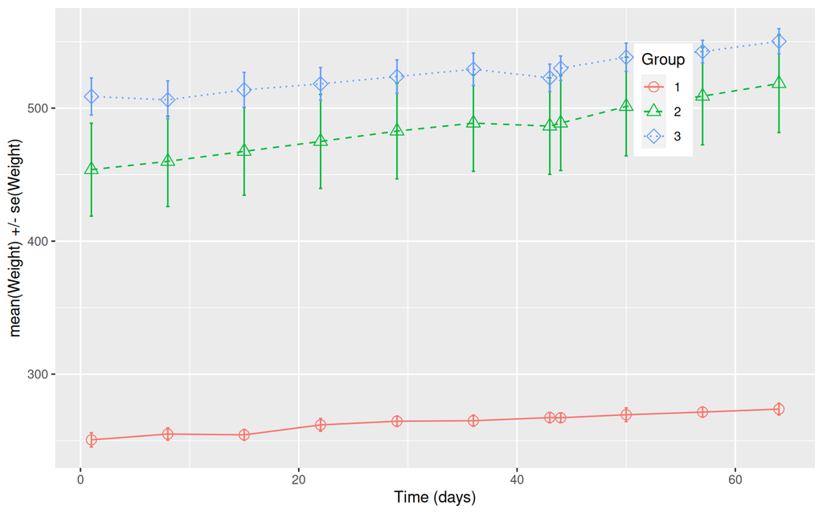

RATS mean weights for different groups with standard errors.

```r
ggplot(rats_me, aes(x = Time, y = Weight_mean, linetype = Group, shape = Group, col = Group)) +
  geom_line() +
  scale_linetype_manual(values = c(1, 2, 3)) +
  geom_point(size = 3) +
  scale_shape_manual(values = c(1, 2, 5)) +
  geom_errorbar(aes(ymin = Weight_mean - Weight_se,
                    ymax = Weight_mean + Weight_se,
                    linetype="1"), width=0.3) +
  theme(legend.position = c(0.8, 0.8)) +
  scale_x_continuous(name = "Time (days)") +
  scale_y_continuous(name = "mean(Weight) +/- se(Weight)")
```

To examine differences between groups, we average weights over individuals in each of the groups and look at the mean development of weights over time. Additionally, we would like information on the variance of weights in each group in order to determine the accuracy of the group means. To do this, we calculate the standard error $\sigma_{\overline{\text{Weight}}} = \sigma_{\text{Weight}}/\sqrt{N}$ based on the standard deviation $\sigma_{\text{Weight}}$ and number of individuals $N$. The mean weights and standard errors are plotted as a function of time in figure @ref(fig:rl6). We can see that there upward trends in weight for all groups. Group 1 has the lowest change between starting weight and final weight, so it has the less growth. Group 1 also has the smallest error in mean weight, which we noted previously. Groups 2 and 3 have similar trends, with group 3 starting at a higher weight than group 2. The mean weights for group 2 appear to increase more during the measurement period than those in group 3. Additionally, there is significant overlap in the errors for groups 2 and 3. This suggests that there could be similarities between the two groups. It could also be that there is some sort of nonlinearity in the growth, so that rats with lower weights have higher growth than those with higher weights.

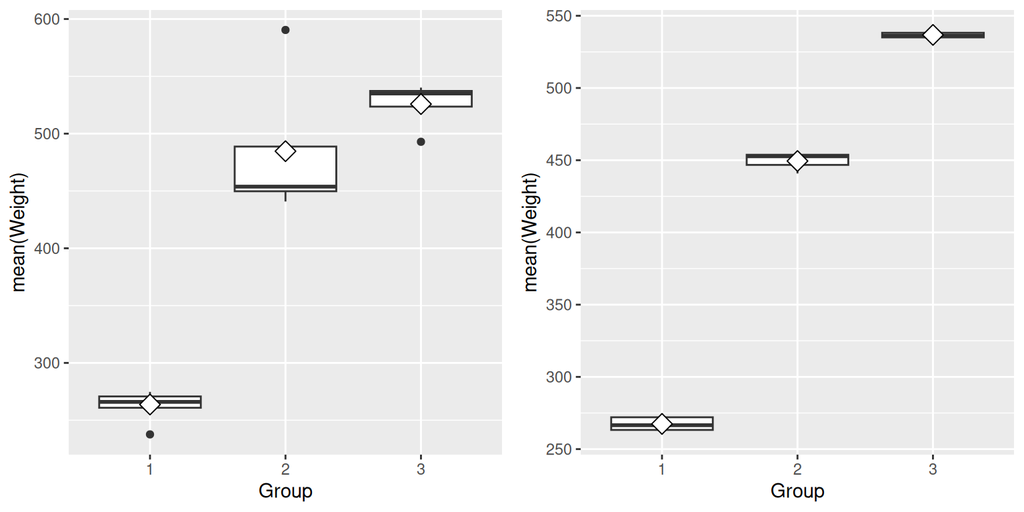

RATS weight box plots for different groups, before (left) and after (right) removal of outliers.

```r
# mean weights for each individual
rats_m <- rats %>%
  filter(Time > 0) %>%
  group_by(Group, ID) %>%
  summarise(Weight_mean = mean(Weight)) %>%
  ungroup()

# filter outliers based on weight
rats_m1 <- rats_m %>%
  filter(case_when(
    Group == 1 ~ Weight_mean > 250,
    Group == 2 ~ Weight_mean < 550,
    Group == 3 ~ Weight_mean > 500
  ))

b1 <- ggplot(rats_m, aes(x = Group, y = Weight_mean)) +
  geom_boxplot() +
  stat_summary(fun = "mean", geom = "point", shape=23, size=4, fill = "white") +
  scale_y_continuous(name = "mean(Weight)")

b2 <- ggplot(rats_m1, aes(x = Group, y = Weight_mean)) +
  geom_boxplot() +
  stat_summary(fun = "mean", geom = "point", shape=23, size=4, fill = "white") +
  scale_y_continuous(name = "mean(Weight)")

grid.arrange(b1, b2, ncol=2, nrow=1)
```

We create a data set that contains the mean weights of each individual and what group they belong to. To look for outliers, we create box plots for each group in figure @ref(fig:rb6). We can see that each of the groups 1, 2 and 3 have one outlier point in figure @ref(fig:rb6) (left). This point can be removed by filtering by the weight of the individual. After these points have been removed, we can see that there are no more outlier points @ref(fig:rb6) (right).

```r
# starting weights for rats in rats_m1
rats_weight0 <- rats %>%
  filter(Time == 1) %>%
  filter(ID %in% rats_m1$ID)

# add starting weights
rats_m2 <- rats_m1 %>%
  mutate(Weight_mean0 = rats_weight0$Weight)

# perform t-tests
rats_t1 <- t.test(Weight_mean ~ Group, data = rats_m2 %>% filter(Group != 1), var.equal = TRUE)
rats_t2 <- t.test(Weight_mean ~ Group, data = rats_m2 %>% filter(Group != 2), var.equal = TRUE)
rats_t3 <- t.test(Weight_mean ~ Group, data = rats_m2 %>% filter(Group != 3), var.equal = TRUE)

kable(data.frame("Groups"=c("Group 1 vs. group 2",
                            "Group 1 vs. group 3",
                            "Group 2 vs. group 3"),
                 "pValue"=c(rats_t3$p.value,
                            rats_t2$p.value,
                            rats_t1$p.value)) %>% format_engr(),
      caption = "RATS group mean weight $t$-test $p$-values.", digits=2) %>%
kable_styling()
```

RATS group mean weight $t$-test $p$-values.

| Groups | pValue |
| --- | --- |
| Group 1 vs. group 2 | ${121.5}\times 10^{-12}$ |
| Group 1 vs. group 3 | ${1.348}\times 10^{-12}$ |
| Group 2 vs. group 3 | ${51.02}\times 10^{-6}$ |

```r
format_summary <- function(s) {
  fe <- s %>% xtable()
  fe <- cbind(rownames(fe), fe %>% format_engr())
  colnames(fe)[1] <- ""
  fe
}

# linear model to predict mean weight of rats based on starting weight and group
rats_lm <- lm(Weight_mean ~ Weight_mean0 + Group, rats_m2)
rats_lm_summary <- summary(rats_lm)
rats_lm_anova <- anova(rats_lm)

kable(format_summary(rats_lm_summary),
     caption = "Summary of RATS linear model.", digits=2) %>%
kable_styling()
```

Summary of RATS linear model.

|  | Estimate | Std. Error | t value | Pr(>\|t\|) |
| --- | --- | --- | --- | --- |
| (Intercept) | $201.2$ | $25.74$ | $7.817$ | ${26.62}\times 10^{-6}$ |
| Weight_mean0 | ${260.5}\times 10^{-3}$ | ${101.0}\times 10^{-3}$ | $2.580$ | ${29.69}\times 10^{-3}$ |
| Group2 | $138.8$ | $17.04$ | $8.147$ | ${19.13}\times 10^{-6}$ |
| Group3 | $199.7$ | $27.19$ | $7.342$ | ${43.62}\times 10^{-6}$ |

```r
kable(format_summary(rats_lm_anova),
     caption = "RATS linear model ANOVA table.", digits=2) %>%
kable_styling()
```

RATS linear model ANOVA table.

|  | Df | Sum Sq | Mean Sq | F value | Pr(>F) |
| --- | --- | --- | --- | --- | --- |
| Weight_mean0 | $1$ | ${174.4}\times 10^{3}$ | ${174.4}\times 10^{3}$ | ${7.999}\times 10^{3}$ | ${13.84}\times 10^{-15}$ |
| Group | $2$ | ${1.707}\times 10^{3}$ | $853.5$ | $39.15$ | ${36.28}\times 10^{-6}$ |
| Residuals | $9$ | $196.2$ | $21.80$ | NA | NA |

We add the starting weights of each individual to the previously created data set. A $t$-test is performed to determine if the mean weights in groups 1, 2 and 3 are different from each other. The $p$-values given by the $t$-test are shown in table @ref(tab:rt6). We can see that the $p$-values are quite low, which suggests that the mean weights are different between groups. A linear model is fitted to predict the mean weight of individuals based on their starting weights and the diet group they belong to. A summary of the parameters of the fit is shown in table @ref(tab:rls6). We can see that the fit is quite good, reaching $p=0.05$ significance level. We run analysis of variance on the fitted model, the results of which are shown in table @ref(tab:rla6). This table shows the goodness of fit for the whole categorical variable `Group`, as well as for the starting weight `Weight_mean0`, both of which show good statistical significance. It appears that most of the variation can be attributed to `Weight_mean0`.

## BPRS

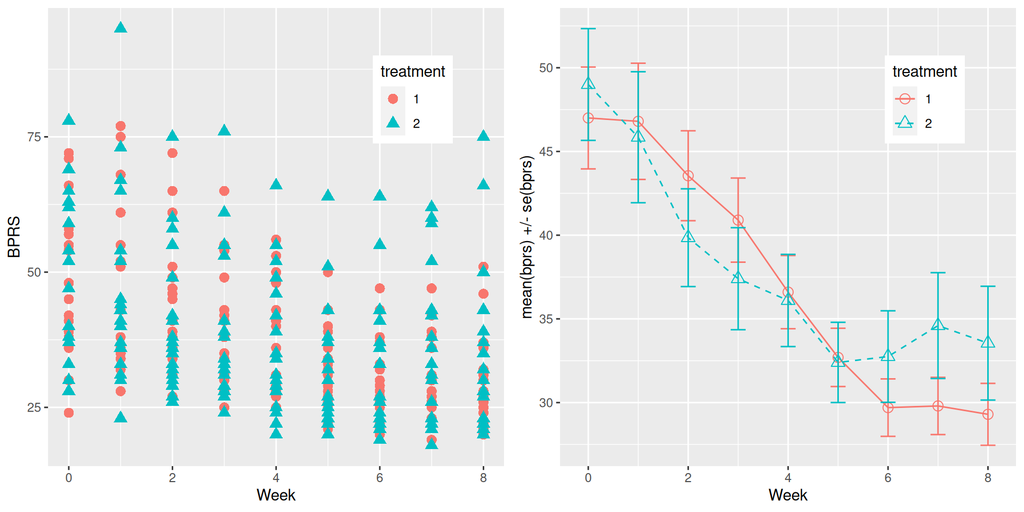

BPRS scores for different individuals and treatments (left) and means with standard errors (right).

```r
# calculate mean bprs and standard errors
bprs_me <- bprs %>%
  group_by(treatment, week) %>%
  summarise(bprs_mean = mean(bprs), bprs_se = sd(bprs)/sqrt(n())) %>%
  ungroup()

m1 <- ggplot(bprs, aes(x = week, y = bprs, linetype = treatment, shape = treatment, col = treatment)) +
  geom_point(size = 3) +
  theme(legend.position = c(0.8, 0.8)) +
  scale_x_continuous(name = "Week") +
  scale_y_continuous(name = "BPRS")

m2 <- ggplot(bprs_me, aes(x = week, y = bprs_mean, linetype = treatment, shape = treatment, col = treatment)) +
  geom_line() +
  scale_linetype_manual(values = c(1, 2, 3)) +
  geom_point(size = 3) +
  scale_shape_manual(values = c(1, 2, 5)) +
  geom_errorbar(aes(ymin = bprs_mean - bprs_se,
                    ymax = bprs_mean + bprs_se,
                    linetype="1"), width=0.3) +
  theme(legend.position = c(0.8, 0.8)) +
  scale_x_continuous(name = "Week") +
  scale_y_continuous(name = "mean(bprs) +/- se(bprs)")

grid.arrange(m1, m2, ncol=2, nrow=1)
```

For the BPRS data set, we want to find out how treatment influences the psychological state of subjects during the measurement period. Different treatments are have likely different effectivenesses, so we want to determine how different treatments perform. In figure @ref(fig:bm6), we have plotted the mean BPRS score and standard errors as a function of time. We can see that overall, the BPRS scores for subjects decrease over the measurement period. We can also see that the variance perhaps decreases, especially for treatment 1.

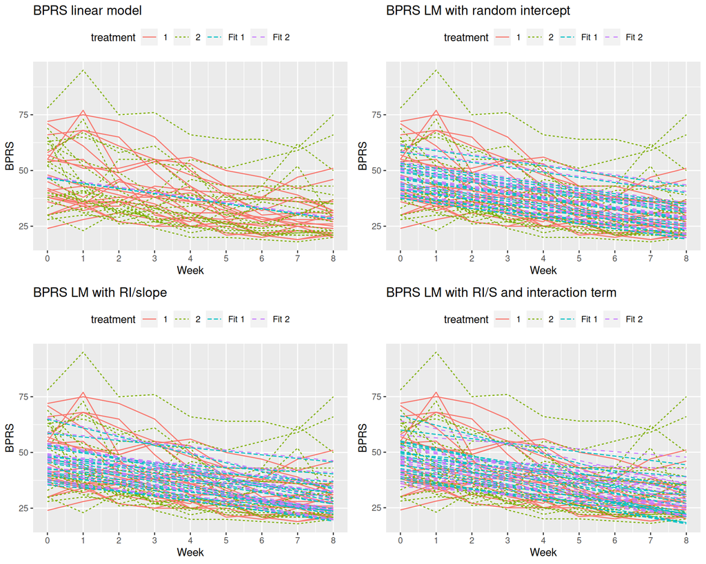

BPRS data (grouped by treatment) and fitted linear models.

```r
plot_fit_data <- function(data, fit, title) {
  data_fit <- data
  data_fit$bprs <- predict(fit)
  data_fit$treatment <- as.factor(paste("Fit", data_fit$treatment))

  ggplot(rbind(data, data_fit), aes(x = week, y = bprs, group = interaction(subject, treatment), col=treatment)) +
    geom_line(aes(linetype = treatment)) +
    scale_x_continuous(name = "Week", breaks = seq(0, 8, 1)) +
    scale_y_continuous(name = "BPRS") +
    theme(legend.position = "top") +
    ggtitle(title)
}

# fit simple linear model
bprs_lm <- lm(bprs ~ week + treatment, bprs)
bprs_lm_summary <- summary(bprs_lm)

bl1 <- plot_fit_data(bprs, bprs_lm, "BPRS linear model")

# fit model with random intercept
bprs_lmri <- lmer(bprs ~ week + treatment + (1 | subject), bprs, REML = F)
bprs_lmri_summary <- summary(bprs_lmri)

bl2 <- plot_fit_data(bprs, bprs_lmri, "BPRS LM with random intercept")

# fit model with random intercept and slope
bprs_lmrs <- lmer(bprs ~ week + treatment + (week | subject), bprs, REML = F)
bprs_lmrs_summary <- summary(bprs_lmrs)
bprs_lmrs_anova <- anova(bprs_lmri, bprs_lmrs)

bl3 <- plot_fit_data(bprs, bprs_lmrs, "BPRS LM with RI/slope")

# fit model with random intercept, random slow and interaction term
bprs_lmrsi <- lmer(bprs ~ week + treatment + week * treatment + (week | subject), bprs, REML = F)
bprs_lmrsi_summary <- summary(bprs_lmrsi)
bprs_lmrsi_anova <- anova(bprs_lmrs, bprs_lmrsi)

bl4 <- plot_fit_data(bprs, bprs_lmrsi, "BPRS LM with RI/S and interaction term")

grid.arrange(bl1, bl2, bl3, bl4, ncol=2, nrow=2)
```

We fit different linear mixed effects models to the BPRS data set to model how the treatment influences the BRPS scores over time. In figure @ref(fig:bl6) we have plotted the BPRS scores for each individual in the two groups over time. In each of these plots, a different model has been fitted.

We start by assuming that the measurements are uncorrelated and fit a simple linear model to predict `bprs` based on the variables `week` and `treatment`. We expect the BPRS to change with time (decrease) and differ with respect to the treatment. A summary of the parameters of the simple linear model is given in table @ref(tab:bls6). The fitted model produces a BPRS score that decreases with time, which matches what we can see in the data. According to the fit, treatment 1 results in a lower BPRS than treatment 2. The fitted model is shown in figure @ref(fig:bl6).

Next, we fit linear mixed effects models using the `lm4` library to take individual random variation into account. A random intercept model is fitted to allow variations between individuals for intercept of the linear model. This done by adding the `(1 | subject)` term, so that the constant in the formula can vary with `subject`. We can see that there are now multiple lines, so each individual has a different prediction. The summary for the fit is given in table @ref(tab:bri6). Random variance for the intercept is 47.41. The fitted model is shown in figure @ref(fig:bl6).

We fit another model by adding a random slope, so that the BPRS rate of change can vary between individuals. This is done by using the term `(week | subject)`. The summary for this fit is given in table @ref(tab:bris6). Random variance for the intercept is 64.82 and variance for `week` is 0.96. The fitted model is shown in figure @ref(fig:bl6).

Summary of BPRS linear model.

|  | Estimate | Std. Error | t value | Pr(>\|t\|) |
| --- | --- | --- | --- | --- |
| (Intercept) | $46.45$ | $1.367$ | $33.98$ | ${6.256}\times 10^{-114}$ |
| week | $-2.270$ | ${252.4}\times 10^{-3}$ | $-8.995$ | ${14.13}\times 10^{-18}$ |
| treatment2 | ${572.2}\times 10^{-3}$ | $1.303$ | ${439.0}\times 10^{-3}$ | ${660.9}\times 10^{-3}$ |

Summary of BPRS linear model with random intercept.

|  | Estimate | Std. Error | t value |
| --- | --- | --- | --- |
| (Intercept) | $46.45$ | $1.909$ | $24.33$ |
| week | $-2.270$ | ${208.4}\times 10^{-3}$ | $-10.90$ |
| treatment2 | ${572.2}\times 10^{-3}$ | $1.076$ | ${531.8}\times 10^{-3}$ |

Summary of BPRS linear model with random intercept and random slow.

|  | Estimate | Std. Error | t value |
| --- | --- | --- | --- |
| (Intercept) | $46.45$ | $2.105$ | $22.07$ |
| week | $-2.270$ | ${297.7}\times 10^{-3}$ | $-7.626$ |
| treatment2 | ${572.2}\times 10^{-3}$ | $1.040$ | ${550.0}\times 10^{-3}$ |

Summary of BPRS linear model with random intercept, random slope and interaction term.

|  | Estimate | Std. Error | t value |
| --- | --- | --- | --- |
| (Intercept) | $47.89$ | $2.252$ | $21.26$ |
| week | $-2.628$ | ${358.9}\times 10^{-3}$ | $-7.323$ |
| treatment2 | $-2.291$ | $1.909$ | $-1.200$ |
| week:treatment2 | ${715.8}\times 10^{-3}$ | ${401.0}\times 10^{-3}$ | $1.785$ |

We run analysis of variance between the linear mixed effects models to determine how changing the model influences the fit. In table @ref(tab:rsa6), the ANOVA table for a comparison between the random intercept model and random intercept + random slope model is given. The comparison between the random intercept + random slope model and random intercept + random slope + interaction term model is given in table @ref(tab:ria6). We can see that adding the interaction term had a smaller effect on the $\chi^2$ than adding the random slope, so the correlation between treatment and time appears to be less significant than individual random variations. Adding the interaction term did not have a statistically significant change on the model, so the differences between treatments seem to be minor.

ANOVA table for BPRS linear models with random intercept vs. RI + random slope.

|  | npar | AIC | BIC | logLik | deviance | Chisq | Df | Pr(>Chisq) |
| --- | --- | --- | --- | --- | --- | --- | --- | --- |
| Random intercept | $5.000$ | ${2.749}\times 10^{3}$ | ${2.768}\times 10^{3}$ | ${-1.369}\times 10^{3}$ | ${2.739}\times 10^{3}$ | NA | NA | NA |
| RI + random slope | $7.000$ | ${2.745}\times 10^{3}$ | ${2.773}\times 10^{3}$ | ${-1.366}\times 10^{3}$ | ${2.731}\times 10^{3}$ | $7.272$ | $2.000$ | ${26.36}\times 10^{-3}$ |

ANOVA table for BPRS linear models with RI + RS vs. RI + RS + interaction term.

|  | npar | AIC | BIC | logLik | deviance | Chisq | Df | Pr(>Chisq) |
| --- | --- | --- | --- | --- | --- | --- | --- | --- |
| RI + RS | $7.000$ | ${2.745}\times 10^{3}$ | ${2.773}\times 10^{3}$ | ${-1.366}\times 10^{3}$ | ${2.731}\times 10^{3}$ | NA | NA | NA |
| RI + RS + interaction | $8.000$ | ${2.744}\times 10^{3}$ | ${2.775}\times 10^{3}$ | ${-1.364}\times 10^{3}$ | ${2.728}\times 10^{3}$ | $3.171$ | $1.000$ | ${74.95}\times 10^{-3}$ |

[^1]: https://raw.githubusercontent.com/KimmoVehkalahti/MABS/master/Examples/data/rats.txt
[^2]: https://raw.githubusercontent.com/KimmoVehkalahti/MABS/master/Examples/data/BPRS.txt